# CAMPANHAS SETEMBRO 2022

18 outubro, 2022

Esse documento é uma análise visual da atividade de campanhas com bonificação em cartões Alelo.

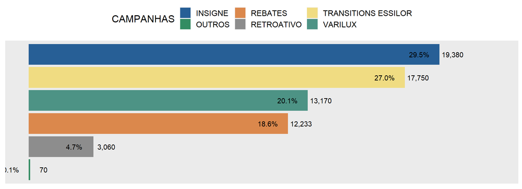

As bonificações Insigne diminuiram em Setembro -8% em relação ao mês anterior .

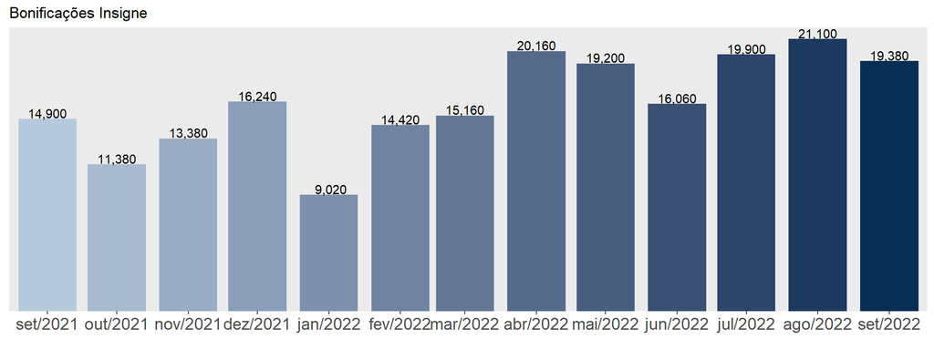

Vendas Insigne cresceram 4,1% em Setembro em relação ao mês anterior.

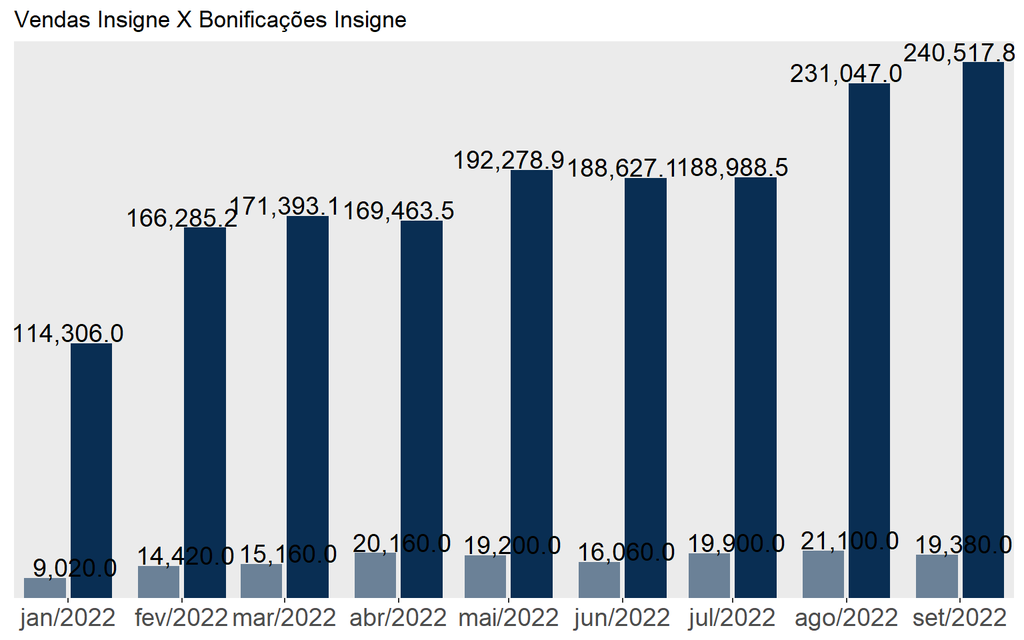

O crescimento em vendas Insigne sem campanha foi de 12% em comparação clientes sem campanha 2%.

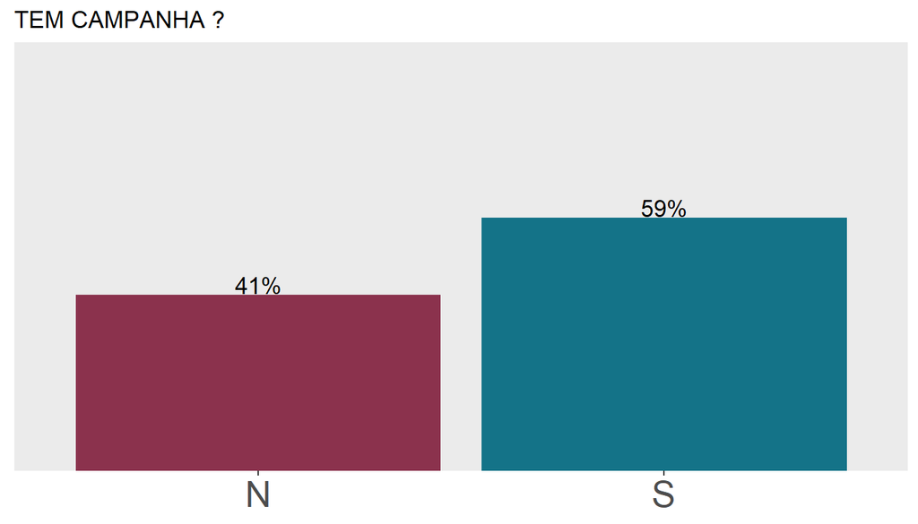

As bonificações em rebates diminuiram -34% % em Setembro comparado com o mês anterior. Em comparação, o faturamento conjunto desses 3 clientes caiu -14 %, a queda mais expressiva foi a Vital -21% .

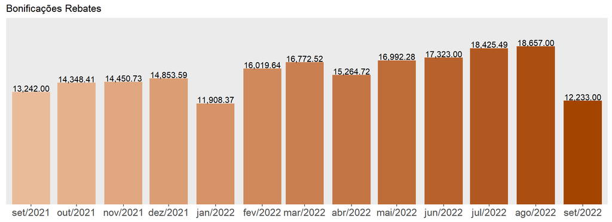

As bonificações em Varilux cresceram 106% em Agosto em comparação com o mês anterior. A bonificação mais expressiva foi a Itaçu 5k.

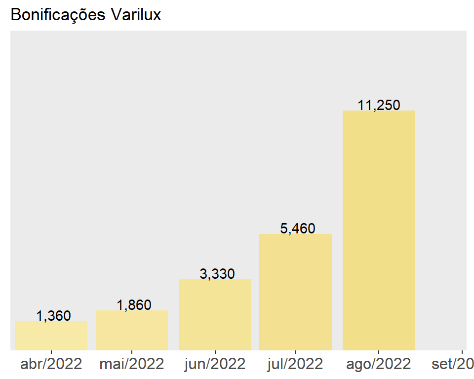

Outras campanhas não tiveram resultado significativo. A recomendação é que sejam encerradas.

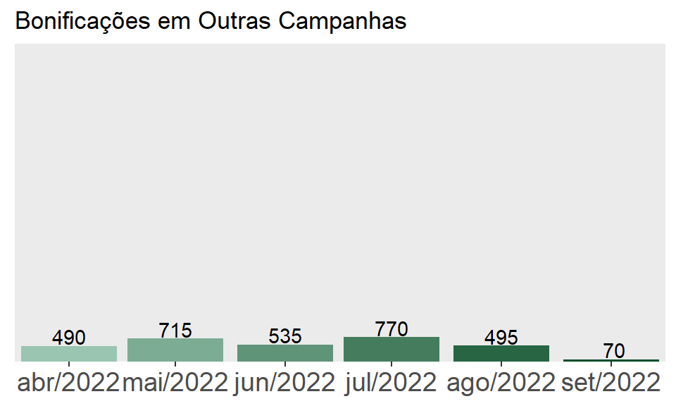

Apenas 1 pagamento retroativo foi pago este mês para a Ótica Luna (654) do Setor 2

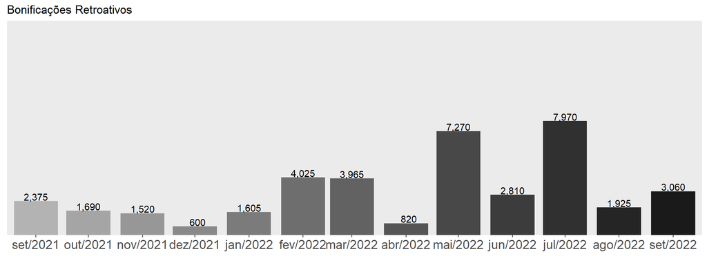